# ALL

Design a distributed application using RPC for remote computation where client submits an integer value to the server and server calculates factorial and returns the result to the client program.

```python
#SERVER
```

```python
# !pip install xmlrpc
```

```python
# Run this in one notebook cell or terminal
from xmlrpc.server import SimpleXMLRPCServer
import math

def factorial(n):
    if n < 0:
        return "Error: Negative number"
    return math.factorial(n)

# Create server
server = SimpleXMLRPCServer(("localhost", 8000), allow_none=True)
print("🖥️ RPC Server is running on port 8000...")

# Register the factorial function
server.register_function(factorial, "compute_factorial")

# Keep server running
server.serve_forever()
```

```python
#CLIENT
```

```python
# Run this in another notebook cell or terminal
import xmlrpc.client

# Connect to the RPC server
proxy = xmlrpc.client.ServerProxy("http://localhost:8000/")

# Input value
n = int(input("Enter a number to compute factorial: "))

# Make remote call
result = proxy.compute_factorial(n)

print(f"✅ Factorial of {n} is: {result}")
```

Design a distributed application using RMI for remote computation where client submits two strings to the server and server returns the concatenation of the given strings.

```python
!pip install Pyro5
```

```
Downloading Pyro5-5.15-py3-none-any.whl (79 kB)
Downloading serpent-1.41-py3-none-any.whl (9.6 kB)
```

```python
# concat_server.py
import Pyro5.api

@Pyro5.api.expose
class ConcatServer:
    def concatenate(self, str1, str2):
        print(f"Received: '{str1}' and '{str2}'")
        return str1 + str2

def main():
    daemon = Pyro5.server.Daemon()                # start server daemon
    uri = daemon.register(ConcatServer)           # register object
    print(f"Server is running. URI: {uri}")
    daemon.requestLoop()                          # wait for requests

if __name__ == "__main__":
    main()
```

```
Server is running. URI: PYRO:obj_ca52bdbc17b44f3e9bd4725841631eff@localhost:64604
```

```python
# concat_client.py
import Pyro5.api

def main():
    uri = input("Enter server URI (e.g., PYRO:obj_xxx@localhost:xxxx): ")
    concat_server = Pyro5.api.Proxy(uri)

    s1 = input("Enter first string: ")
    s2 = input("Enter second string: ")

    result = concat_server.concatenate(s1, s2)
    print(f"Concatenated Result: {result}")

if __name__ == "__main__":
    main()
```

Implement Union, Intersection, Complement and Difference operations on fuzzy sets. Also create fuzzy relations by Cartesian product of any two fuzzy sets and perform max-min composition on any two fuzzy relations.

```python
import numpy as np

# Function to perform Union operation on fuzzy sets
def fuzzy_union(A, B):
    return np.maximum(A, B)

# Function to perform Intersection operation on fuzzy sets
def fuzzy_intersection(A, B):
    return np.minimum(A, B)

# Function to perform Complement operation on a fuzzy set
def fuzzy_complement(A):
    return 1 - A

# Function to perform Difference operation on fuzzy sets
def fuzzy_difference(A, B):
    return np.maximum(A, 1 - B)

# Function to create fuzzy relation by Cartesian product of two fuzzy sets
def cartesian_product(A, B):
    return np.outer(A, B)

# Function to perform Max-Min composition on two fuzzy relations
def max_min_composition(R, S):
    return np.max(np.minimum.outer(R, S), axis=1)

# Example usage
A = np.array([0.2, 0.4, 0.6, 0.8])  # Fuzzy set A
B = np.array([0.3, 0.5, 0.7, 0.9])  # Fuzzy set B

# Operations on fuzzy sets
union_result = fuzzy_union(A, B)
intersection_result = fuzzy_intersection(A, B)
complement_A = fuzzy_complement(A)
difference_result = fuzzy_difference(A, B)

print("Union:", union_result)
print("Intersection:", intersection_result)
print("Complement of A:", complement_A)
print("Difference:", difference_result)

# Fuzzy relations
R = np.array([0.2, 0.5, 0.4])  # Fuzzy relation R
S = np.array([0.6, 0.3, 0.7])  # Fuzzy relation S

# Cartesian product of fuzzy relations
cartesian_result = cartesian_product(R, S)

# Max-Min composition of fuzzy relations
composition_result = max_min_composition(R, S)

print("Cartesian product of R and S:")
print(cartesian_result)

print("Max-Min composition of R and S:")
print(composition_result)
```

```
Union: [0.3 0.5 0.7 0.9]
Intersection: [0.2 0.4 0.6 0.8]
Complement of A: [0.8 0.6 0.4 0.2]
Difference: [0.7 0.5 0.6 0.8]
Cartesian product of R and S:
[[0.12 0.06 0.14]
 [0.3  0.15 0.35]
 [0.24 0.12 0.28]]
Max-Min composition of R and S:
[0.2 0.5 0.4]
```

```python
#OR
```

```python
import numpy as np
import pandas as pd

# -----------------------------
# 🔶 Define two fuzzy sets
# -----------------------------
# Format: {element: membership_value}
A = {'a': 0.2, 'b': 0.7, 'c': 0.5}
B = {'a': 0.6, 'b': 0.4, 'c': 0.9}

universe = sorted(set(A.keys()) | set(B.keys()))

# -----------------------------
# 🔁 Fuzzy Set Operations
# -----------------------------
def fuzzy_union(A, B):
    return {x: max(A.get(x, 0), B.get(x, 0)) for x in universe}

def fuzzy_intersection(A, B):
    return {x: min(A.get(x, 0), B.get(x, 0)) for x in universe}

def fuzzy_complement(A):
    return {x: 1 - A.get(x, 0) for x in universe}

def fuzzy_difference(A, B):
    return {x: min(A.get(x, 0), 1 - B.get(x, 0)) for x in universe}

# -----------------------------
# 🔗 Cartesian Product (Fuzzy Relation)
# -----------------------------
def cartesian_product(X, Y):
    return {(x, y): min(X[x], Y[y]) for x in X for y in Y}

# -----------------------------
# 🔁 Max-Min Composition
# -----------------------------
def max_min_composition(R1, R2):
    X = sorted(set(x for (x, y) in R1.keys()))
    Z = sorted(set(z for (y, z) in R2.keys()))
    Y = sorted(set(y for (x, y) in R1.keys()))

    composition = {}
    for x in X:
        for z in Z:
            min_vals = [min(R1.get((x, y), 0), R2.get((y, z), 0)) for y in Y]
            composition[(x, z)] = max(min_vals)
    return composition

# -----------------------------
# 🧪 Demonstration
# -----------------------------

print("✅ Fuzzy Set A:", A)
print("✅ Fuzzy Set B:", B)

union = fuzzy_union(A, B)
intersection = fuzzy_intersection(A, B)
complement_A = fuzzy_complement(A)
difference = fuzzy_difference(A, B)

print("\n🔹 Union A ∪ B:", union)
print("🔹 Intersection A ∩ B:", intersection)
print("🔹 Complement A':", complement_A)
print("🔹 Difference A - B:", difference)

# Create fuzzy relations via cartesian product
R1 = cartesian_product(A, B)
R2 = cartesian_product(B, A)

# Show fuzzy relation R1 as a DataFrame
print("\n📋 Fuzzy Relation R1 (A × B):")
df_R1 = pd.DataFrame(index=A.keys(), columns=B.keys())
for (x, y), val in R1.items():
    df_R1.loc[x, y] = round(val, 2)
display(df_R1.fillna('-'))

# Show fuzzy relation R2 as a DataFrame
print("\n📋 Fuzzy Relation R2 (B × A):")
df_R2 = pd.DataFrame(index=B.keys(), columns=A.keys())
for (x, y), val in R2.items():
    df_R2.loc[x, y] = round(val, 2)
display(df_R2.fillna('-'))

# Perform Max-Min Composition
composition = max_min_composition(R1, R2)

# Show composition as a matrix
print("\n🔁 Max-Min Composition (R1 ○ R2):")
composition_df = pd.DataFrame(index=A.keys(), columns=A.keys())
for (x, z), val in composition.items():
    composition_df.loc[x, z] = round(val, 2)
display(composition_df.fillna('-'))
```

```
✅ Fuzzy Set A: {'a': 0.2, 'b': 0.7, 'c': 0.5}
✅ Fuzzy Set B: {'a': 0.6, 'b': 0.4, 'c': 0.9}

🔹 Union A ∪ B: {'a': 0.6, 'b': 0.7, 'c': 0.9}
🔹 Intersection A ∩ B: {'a': 0.2, 'b': 0.4, 'c': 0.5}
🔹 Complement A': {'a': 0.8, 'b': 0.30000000000000004, 'c': 0.5}
🔹 Difference A - B: {'a': 0.2, 'b': 0.6, 'c': 0.09999999999999998}

📋 Fuzzy Relation R1 (A × B):
```

|  | a | b | c |
| --- | --- | --- | --- |
| a | 0.2 | 0.2 | 0.2 |
| b | 0.6 | 0.4 | 0.7 |
| c | 0.5 | 0.4 | 0.5 |

```
📋 Fuzzy Relation R2 (B × A):
```

|  | a | b | c |
| --- | --- | --- | --- |
| a | 0.2 | 0.6 | 0.5 |
| b | 0.2 | 0.4 | 0.4 |
| c | 0.2 | 0.7 | 0.5 |

```
🔁 Max-Min Composition (R1 ○ R2):
```

|  | a | b | c |
| --- | --- | --- | --- |
| a | 0.2 | 0.2 | 0.2 |
| b | 0.2 | 0.7 | 0.5 |
| c | 0.2 | 0.5 | 0.5 |

Write code to simulate requests coming from clients and distribute them among the servers using the load balancing algorithms.

```python
import random

# Define servers with weights and active connections
servers = [
    {'name': 'Server1', 'weight': 2, 'connections': 0},
    {'name': 'Server2', 'weight': 1, 'connections': 0},
    {'name': 'Server3', 'weight': 3, 'connections': 0},
]

# Simulate client requests
requests = ['Request' + str(i) for i in range(1, 11)]  # 10 client requests

# ---------- Round Robin ----------
print("----- Round Robin Load Balancing -----")
server_index = 0
for req in requests:
    assigned_server = servers[server_index]['name']
    print(f"{req} --> {assigned_server}")
    server_index = (server_index + 1) % len(servers)

# ---------- Random Selection ----------
print("\n----- Random Selection Load Balancing -----")
for req in requests:
    assigned_server = random.choice(servers)['name']
    print(f"{req} --> {assigned_server}")

# ---------- Weighted Round Robin ----------
print("\n----- Weighted Round Robin Load Balancing -----")
# Expand servers list based on weights
weighted_servers = []
for server in servers:
    weighted_servers.extend([server['name']] * server['weight'])

server_index = 0
for req in requests:
    assigned_server = weighted_servers[server_index]
    print(f"{req} --> {assigned_server}")
    server_index = (server_index + 1) % len(weighted_servers)

# ---------- Least Connections ----------
print("\n----- Least Connections Load Balancing -----")
# Reset connections
for server in servers:
    server['connections'] = 0

for req in requests:
    # Find server with least connections
    least_conn_server = min(servers, key=lambda s: s['connections'])
    least_conn_server['connections'] += 1  # Add one connection
    print(f"{req} --> {least_conn_server['name']}")

# Show final connection counts
print("\nFinal connections per server:")
for server in servers:
    print(f"{server['name']}: {server['connections']} connections")
```

```
----- Round Robin Load Balancing -----
Request1 --> Server1
Request2 --> Server2
Request3 --> Server3
Request4 --> Server1
Request5 --> Server2
Request6 --> Server3
Request7 --> Server1
Request8 --> Server2
Request9 --> Server3
Request10 --> Server1

----- Random Selection Load Balancing -----
Request1 --> Server3
Request2 --> Server3
Request3 --> Server2
Request4 --> Server1
Request5 --> Server1
Request6 --> Server2
Request7 --> Server2
Request8 --> Server3
Request9 --> Server3
Request10 --> Server3

----- Weighted Round Robin Load Balancing -----
Request1 --> Server1
Request2 --> Server1
Request3 --> Server2
Request4 --> Server3
Request5 --> Server3
Request6 --> Server3
Request7 --> Server1
Request8 --> Server1
Request9 --> Server2
Request10 --> Server3

----- Least Connections Load Balancing -----
Request1 --> Server1
Request2 --> Server2
Request3 --> Server3
Request4 --> Server1
Request5 --> Server2
Request6 --> Server3
Request7 --> Server1
Request8 --> Server2
Request9 --> Server3
Request10 --> Server1

Final connections per server:
Server1: 4 connections
Server2: 3 connections
Server3: 3 connections
```

```python
#OR OPTIONAL
```

```
----- Least Connections Load Balancing with Threads -----
Request1 --> Server1 (processing...)
Request2 --> Server2 (processing...)
Request3 --> Server3 (processing...)
Request4 --> Server1 (processing...)
Request5 --> Server2 (processing...)
Request6 --> Server3 (processing...)
Request7 --> Server1 (processing...)
Request8 --> Server2 (processing...)
Request9 --> Server3 (processing...)
Request10 --> Server1 (processing...)
Request11 --> Server2 (processing...)
Request12 --> Server3 (processing...)
Request13 --> Server1 (processing...)
Request14 --> Server2 (processing...)
Request15 --> Server3 (processing...)
Request16 --> Server1 (processing...)
Request17 --> Server2 (processing...)
Request18 --> Server3 (processing...)
Request19 --> Server1 (processing...)
Request20 --> Server2 (processing...)
Request12 --> Server3 (completed)Request9 --> Server3 (completed)
Request18 --> Server3 (completed)
Request16 --> Server1 (completed)

Request1 --> Server1 (completed)
Request5 --> Server2 (completed)
Request19 --> Server1 (completed)
Request6 --> Server3 (completed)
Request8 --> Server2 (completed)
Request11 --> Server2 (completed)
Request10 --> Server1 (completed)
Request20 --> Server2 (completed)
Request4 --> Server1 (completed)
Request14 --> Server2 (completed)
Request15 --> Server3 (completed)Request13 --> Server1 (completed)

Request2 --> Server2 (completed)
Request17 --> Server2 (completed)
Request3 --> Server3 (completed)
Request7 --> Server1 (completed)

Final handled requests per server:
Server1: 7 requests
Server2: 7 requests
Server3: 6 requests
```

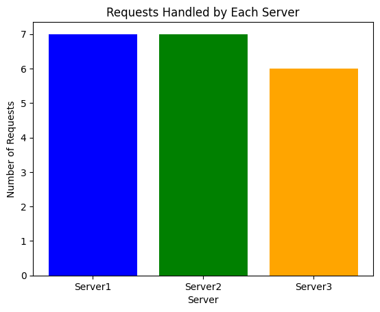

```python
import random
import threading
import time
import matplotlib.pyplot as plt

# Define servers with weights and active connections
servers = [
    {'name': 'Server1', 'weight': 2, 'connections': 0, 'handled': 0},
    {'name': 'Server2', 'weight': 1, 'connections': 0, 'handled': 0},
    {'name': 'Server3', 'weight': 3, 'connections': 0, 'handled': 0},
]

# Simulate client requests
requests = ['Request' + str(i) for i in range(1, 21)]  # 20 client requests

# Simulate random processing time (1-3 seconds)
def process_request(server, req):
    server['connections'] += 1
    server['handled'] += 1
    print(f"{req} --> {server['name']} (processing...)")
    time.sleep(random.uniform(1, 3))  # simulate work
    server['connections'] -= 1
    print(f"{req} --> {server['name']} (completed)")

# ---------- Least Connections with Threading ----------
print("\n----- Least Connections Load Balancing with Threads -----")
threads = []

for req in requests:
    # Find server with least connections
    least_conn_server = min(servers, key=lambda s: s['connections'])
    t = threading.Thread(target=process_request, args=(least_conn_server, req))
    threads.append(t)
    t.start()

# Wait for all threads to finish
for t in threads:
    t.join()

# Show final request handling count
print("\nFinal handled requests per server:")
for server in servers:
    print(f"{server['name']}: {server['handled']} requests")

# ---------- Plotting ----------
server_names = [server['name'] for server in servers]
handled_counts = [server['handled'] for server in servers]

plt.bar(server_names, handled_counts, color=['blue', 'green', 'orange'])
plt.title('Requests Handled by Each Server')
plt.xlabel('Server')
plt.ylabel('Number of Requests')
plt.show()
```

Optimization of Genetic Algorithm Parameters in Hybrid Genetic Algorithm-Neural Network Modeling: Application to Spray Drying of Coconut Milk

```python
#!pip install deap
```

```python
import random
from deap import base, creator, tools, algorithms

# Define evaluation function (this is a mock function, replace this with your actual evaluation function)
def evaluate(individual):
    # Here 'individual' represents the parameters for the neural network
    # You'll need to replace this with your actual evaluation function that trains the neural network and evaluates its performance
    # Return a fitness value (here, a random number is used as an example)
    return random.random(),

# Define genetic algorithm parameters
POPULATION_SIZE = 10
GENERATIONS = 5

# Create types for fitness and individuals in the genetic algorithm
creator.create("FitnessMin", base.Fitness, weights=(-1.0,))
creator.create("Individual", list, fitness=creator.FitnessMin)

# Initialize toolbox
toolbox = base.Toolbox()

# Define attributes and individuals
toolbox.register("attr_neurons", random.randint, 1, 100)  # Example: number of neurons
toolbox.register("attr_layers", random.randint, 1, 5)  # Example: number of layers
toolbox.register("individual", tools.initCycle, creator.Individual, (toolbox.attr_neurons, toolbox.attr_layers), n=1)
toolbox.register("population", tools.initRepeat, list, toolbox.individual)

# Genetic operators
toolbox.register("evaluate", evaluate)
toolbox.register("mate", tools.cxTwoPoint)
toolbox.register("mutate", tools.mutUniformInt, low=1, up=100, indpb=0.2)
toolbox.register("select", tools.selTournament, tournsize=3)

# Create initial population
population = toolbox.population(n=POPULATION_SIZE)

# Run the genetic algorithm
for gen in range(GENERATIONS):
    offspring = algorithms.varAnd(population, toolbox, cxpb=0.5, mutpb=0.1)

    fitnesses = toolbox.map(toolbox.evaluate, offspring)
    for ind, fit in zip(offspring, fitnesses):
        ind.fitness.values = fit

    population = toolbox.select(offspring, k=len(population))

# Get the best individual from the final population
best_individual = tools.selBest(population, k=1)[0]
best_params = best_individual

# Print the best parameters found
print("Best Parameters:", best_params)
```

```
Best Parameters: [41, 2]
```

```python
#OR
```

```python
import numpy as np
from sklearn.neural_network import MLPRegressor
from sklearn.model_selection import train_test_split
from sklearn.metrics import mean_squared_error
import random

# ------------------------------
# 1. Create a simple synthetic dataset
# ------------------------------
# Let's simulate some spray drying data:
# Inputs: inlet_temp, feed_rate, maltodextrin_pct, atomization_pressure
# Output: moisture_content (target variable)

np.random.seed(42)  # for reproducible results

# Generate 200 samples
n_samples = 200
inlet_temp = np.random.uniform(150, 200, n_samples)           # degrees Celsius
feed_rate = np.random.uniform(5, 15, n_samples)               # mL/min
maltodextrin = np.random.uniform(0, 20, n_samples)            # percent
atom_pressure = np.random.uniform(1, 3, n_samples)            # bar

# Simulated target with some noise
moisture = (
    50
    - 0.1 * inlet_temp
    + 0.5 * feed_rate
    + 0.2 * maltodextrin
    - 2 * atom_pressure
    + np.random.normal(0, 1, n_samples)  # noise
)

# Stack inputs into a feature matrix
X = np.column_stack([inlet_temp, feed_rate, maltodextrin, atom_pressure])
y = moisture

# Split into train and test sets
X_train, X_test, y_train, y_test = train_test_split(X, y, test_size=0.2, random_state=1)

# ------------------------------
# 2. Define the GA components
# ------------------------------
# We're optimizing:
# - number of hidden neurons (5 to 20)
# - learning rate (0.0001 to 0.01)
# - mutation rate (0.01 to 0.3)
# - crossover rate (0.5 to 0.9)

POP_SIZE = 10
N_GENERATIONS = 5

# Helper to create a random individual
def create_individual():
    return {
        'hidden_neurons': random.randint(5, 20),
        'learning_rate': random.uniform(0.0001, 0.01),
        'mutation_rate': random.uniform(0.01, 0.3),
        'crossover_rate': random.uniform(0.5, 0.9),
    }

# Fitness: lower MSE is better
def fitness(ind):
    # Create the neural network with given hyperparameters
    model = MLPRegressor(
        hidden_layer_sizes=(ind['hidden_neurons'],),
        learning_rate_init=ind['learning_rate'],
        max_iter=200,
        random_state=1
    )
    # Train
    model.fit(X_train, y_train)
    # Predict
    preds = model.predict(X_test)
    # Compute mean squared error
    mse = mean_squared_error(y_test, preds)
    return mse

# Selection: tournament selection
def tournament_selection(pop, scores, k=3):
    selected = random.sample(list(zip(pop, scores)), k)
    selected.sort(key=lambda x: x[1])  # sort by fitness (mse)
    return selected[0][0]  # return individual with best fitness

# Crossover: single-point on our dict values
def crossover(parent1, parent2, rate):
    child1, child2 = parent1.copy(), parent2.copy()
    if random.random() < rate:
        # swap hidden_neurons and learning_rate
        child1['hidden_neurons'], child2['hidden_neurons'] = parent2['hidden_neurons'], parent1['hidden_neurons']
        child1['learning_rate'], child2['learning_rate'] = parent2['learning_rate'], parent1['learning_rate']
    return child1, child2

# Mutation: tweak each parameter slightly
def mutate(ind, rate):
    if random.random() < rate:
        ind['hidden_neurons'] = random.randint(5, 20)
    if random.random() < rate:
        ind['learning_rate'] = random.uniform(0.0001, 0.01)
    if random.random() < rate:
        ind['mutation_rate'] = random.uniform(0.01, 0.3)
    # Note: we generally don't mutate crossover_rate here for simplicity
    return ind

# ------------------------------
# 3. Run the GA
# ------------------------------
# Initialize population
population = [create_individual() for _ in range(POP_SIZE)]

for gen in range(N_GENERATIONS):
    # Evaluate fitness for each individual
    fitness_scores = [fitness(ind) for ind in population]

    # Print best fitness this generation
    best_idx = np.argmin(fitness_scores)
    print(f"Generation {gen}: Best MSE = {fitness_scores[best_idx]:.4f}")

    # Create new population
    new_pop = []
    while len(new_pop) < POP_SIZE:
        # Select parents
        p1 = tournament_selection(population, fitness_scores)
        p2 = tournament_selection(population, fitness_scores)
        # Crossover
        c1, c2 = crossover(p1, p2, p1['crossover_rate'])
        # Mutate
        c1 = mutate(c1, c1['mutation_rate'])
        c2 = mutate(c2, c2['mutation_rate'])
        new_pop.extend([c1, c2])
    population = new_pop[:POP_SIZE]  # keep population size constant

# After final generation, print the best solution
final_scores = [fitness(ind) for ind in population]
best_idx = np.argmin(final_scores)
best_ind = population[best_idx]
print("\nBest hyperparameters found:")
print(best_ind)
print(f"With MSE = {final_scores[best_idx]:.4f}")
```

```
Generation 0: Best MSE = 14.2386
```

```
Generation 1: Best MSE = 13.8090
```

```
Generation 2: Best MSE = 13.8090
```

```
Generation 3: Best MSE = 13.8090
```

```
Generation 4: Best MSE = 13.8090
```

```
Best hyperparameters found:
{'hidden_neurons': 20, 'learning_rate': 0.007294770861170625, 'mutation_rate': 0.18704482005224912, 'crossover_rate': 0.6914150580422299}
With MSE = 13.8090
```

Implementation of Clonal selection algorithm using Python.

```python
import random

# --- Problem setup ---
# Define a target bit‑string (the “antigen”) we want to match
ANTIGEN = [1, 0, 1, 1, 0, 1, 0, 0]

# CSA parameters
POP_SIZE    = 10    # number of antibodies in the population
N_GENERATIONS = 5   # how many iterations to run
CLONE_FACTOR  = 2   # base number of clones per unit of affinity
MUTATION_RATE = 0.1 # chance to flip each bit in a clone

# --- Helper functions ---
def random_antibody(length):
    """Make a random bit‑string of given length."""
    return [random.choice([0,1]) for _ in range(length)]

def affinity(ab):
    """Affinity = number of matching bits to the antigen."""
    return sum(1 for bit_ab, bit_ag in zip(ab, ANTIGEN) if bit_ab == bit_ag)

def mutate(ab):
    """Flip each bit with probability = MUTATION_RATE."""
    return [
        (1-bit if random.random() < MUTATION_RATE else bit)
        for bit in ab
    ]

# --- Initialize population ---
population = [random_antibody(len(ANTIGEN)) for _ in range(POP_SIZE)]

# --- Main CSA loop ---
for gen in range(1, N_GENERATIONS+1):
    # 1. Evaluate affinity of each antibody
    scores = [(affinity(ab), ab) for ab in population]
    scores.sort(reverse=True, key=lambda x: x[0])  # highest affinity first

    # Print best score this generation
    best_score, best_ab = scores[0]
    print(f"Gen {gen}: Best affinity = {best_score}/{len(ANTIGEN)}  {best_ab}")

    # 2. Select top half for cloning
    n_select = POP_SIZE // 2
    selected = [ab for (_, ab) in scores[:n_select]]

    # 3. Clone and hypermutate
    clones = []
    for ab in selected:
        n_clones = CLONE_FACTOR * affinity(ab)
        for _ in range(n_clones):
            clone = mutate(ab.copy())
            clones.append(clone)

    # 4. Re‑evaluate clones and pick the best to form new population
    clone_scores = [(affinity(c), c) for c in clones]
    # Fill new population with best clones; if too few, pad with random
    clone_scores.sort(reverse=True, key=lambda x: x[0])
    new_pop = [c for (_, c) in clone_scores[:POP_SIZE]]

    # If we lost diversity, inject some new random antibodies
    while len(new_pop) < POP_SIZE:
        new_pop.append(random_antibody(len(ANTIGEN)))

    population = new_pop

# --- Final result ---
final_scores = [(affinity(ab), ab) for ab in population]
final_scores.sort(reverse=True, key=lambda x: x[0])
best_final, best_ab_final = final_scores[0]
print("\nFinal best match:")
print(f"Affinity = {best_final}/{len(ANTIGEN)}  Antibody = {best_ab_final}")
```

```
Gen 1: Best affinity = 7/8  [0, 0, 1, 1, 0, 1, 0, 0]
Gen 2: Best affinity = 8/8  [1, 0, 1, 1, 0, 1, 0, 0]
Gen 3: Best affinity = 8/8  [1, 0, 1, 1, 0, 1, 0, 0]
Gen 4: Best affinity = 8/8  [1, 0, 1, 1, 0, 1, 0, 0]
Gen 5: Best affinity = 8/8  [1, 0, 1, 1, 0, 1, 0, 0]

Final best match:
Affinity = 8/8  Antibody = [1, 0, 1, 1, 0, 1, 0, 0]
```

```python
#Theory
'''
1. Biological Inspiration
CSA comes from the way our adaptive immune system “learns” to recognize and fight pathogens:

Antigen presentation: A foreign substance (antigen) enters the body.

B‑cell activation: A small set of B‑cells whose receptors match the antigen are selected.

Clonal expansion: Those matching B‑cells proliferate (make clones).

Hypermutation: Cloned B‑cells mutate their receptors at a high rate—some mutations improve binding.

Affinity maturation: The highest‑affinity clones are further selected, while poor ones die off.

Memory: Some high‑affinity cells become long‑lived “memory” cells for faster future response.

CSA abstracts that process to solve optimization and pattern‑matching tasks.

2. Algorithm Workflow
At a high level, CSA maintains a population of candidate solutions (“antibodies”) which evolve to better fit a target (“antigen”) or to optimize some objective.

Initialization
• Generate an initial random population of antibodies (solutions).

Affinity Evaluation
• Compute an affinity (fitness) score for each antibody—e.g., similarity to a target pattern or the value of an objective function.

Selection of High‑Affinity Individuals
• Pick the top k antibodies by affinity.
• These will be “cloned.”

Clonal Expansion
• Produce multiple copies of each selected antibody.
• Often the number of clones is proportional to its affinity (better solutions spawn more clones).

Hypermutation
• Mutate each clone’s parameters at a rate inversely proportional to its affinity:

High‑affinity clones mutate less (they’re already good).

Lower‑affinity clones mutate more (to explore new variants).

Re‑Evaluation and Replacement
• Evaluate the mutated clones’ affinities.
• Form the new population by selecting the best clones (and optionally some of the original antibodies or fresh random ones to preserve diversity).

Iteration
• Repeat steps 2–6 for a fixed number of generations or until convergence.

4. Key Parameters and Variations
Population size (N) and selection size (n)

Clone count function: linear or exponential w.r.t. affinity

Mutation schedule: often inverse‑affinity, but some variants use fixed or adaptive rates

Diversity maintenance: injecting random antibodies or using aging to remove stale ones

Memory set: explicitly keep top performers across generations

5. Applications
Pattern Recognition & Classification

Handwriting recognition, face detection, medical diagnosis.

Anomaly / Intrusion Detection

Network security systems that learn “normal” traffic and flag deviations.

Continuous & Combinatorial Optimization

Engineering design (e.g., antenna shapes), resource allocation, scheduling, TSP.

Feature Selection

Selecting subsets of variables in machine learning to improve accuracy and reduce cost.

Robotics & Control

Evolving control laws or path‑planning strategies in dynamic environments.

Function Approximation & Regression

Tuning parameters of neural networks or fuzzy systems (often in hybrid schemes).
'''
```

Applying Artificial Immune Pattern Recognition for Structure Damage Classification

```python
import numpy as np

# Generate dummy data for demonstration purposes (replace this with your actual data)
def generate_dummy_data(samples=100, features=10):
    data = np.random.rand(samples, features)
    labels = np.random.randint(0, 2, size=samples)
    return data, labels

# Define the AIRS algorithm
class AIRS:
    def __init__(self, num_detectors=10, hypermutation_rate=0.1):
        self.num_detectors = num_detectors
        self.hypermutation_rate = hypermutation_rate

    def train(self, X, y):
        self.detectors = X[np.random.choice(len(X), self.num_detectors, replace=False)]

    def predict(self, X):
        predictions = []
        for sample in X:
            distances = np.linalg.norm(self.detectors - sample, axis=1)
            prediction = int(np.argmin(distances))
            predictions.append(prediction)
        return predictions

# Generate dummy data
data, labels = generate_dummy_data()

# Split data into training and testing sets
split_ratio = 0.8
split_index = int(split_ratio * len(data))
train_data, test_data = data[:split_index], data[split_index:]
train_labels, test_labels = labels[:split_index], labels[split_index:]

# Initialize and train AIRS
airs = AIRS(num_detectors=10, hypermutation_rate=0.1)
airs.train(train_data, train_labels)

# Test AIRS on the test set
predictions = airs.predict(test_data)

# Evaluate accuracy
accuracy = float(np.mean(predictions == test_labels))
print(f"Accuracy: {accuracy}")
```

```
Accuracy: 0.15
```

```python
#OR
```

```python
import numpy as np
import random
from sklearn.model_selection import train_test_split
from sklearn.metrics import classification_report

# --- 1. Create a simple synthetic dataset ---
# Let's simulate a 2D feature vector for each measurement:
#   feature_1 and feature_2 could be e.g. vibration amplitudes
N_SAMPLES = 200
# Healthy (self) cluster around (2,2), damaged (non-self) around (5,5)
healthy = np.random.normal(loc=2.0, scale=0.5, size=(N_SAMPLES//2, 2))
damaged = np.random.normal(loc=5.0, scale=0.5, size=(N_SAMPLES//2, 2))

X = np.vstack([healthy, damaged])
y = np.array([0]*(N_SAMPLES//2) + [1]*(N_SAMPLES//2))  # 0=healthy, 1=damaged

# Split into train (to generate detectors) and test (to classify)
X_train, X_test, y_train, y_test = train_test_split(X, y, test_size=0.3, random_state=1)

# --- 2. Negative Selection: generate detectors ---
# A detector is a random point in feature space that is > threshold from all self samples.
SELF = X_train[y_train == 0]
DETECTOR_COUNT = 50
THRESHOLD = 1.0   # minimum Euclidean distance from any self-sample

def generate_detector():
    """Create one detector that doesn't match any healthy (self) pattern."""
    while True:
        # sample uniformly in the overall feature range
        candidate = np.random.uniform(low=X.min(axis=0), high=X.max(axis=0))
        # compute distances to all self samples
        dists = np.linalg.norm(SELF - candidate, axis=1)
        if np.all(dists > THRESHOLD):
            return candidate

# build the detector set
detectors = np.array([generate_detector() for _ in range(DETECTOR_COUNT)])

# --- 3. Classification function ---
def classify(sample):
    """If any detector is within THRESHOLD of sample ⇒ flagged as damaged (1)."""
    dists = np.linalg.norm(detectors - sample, axis=1)
    return 1 if np.any(dists < THRESHOLD) else 0

# --- 4. Evaluate on test set ---
y_pred = np.array([classify(x) for x in X_test])

print(classification_report(y_test, y_pred, target_names=['Healthy','Damaged']))
```

```
              precision    recall  f1-score   support

     Healthy       1.00      0.97      0.98        30
     Damaged       0.97      1.00      0.98        30

    accuracy                           0.98        60
   macro avg       0.98      0.98      0.98        60
weighted avg       0.98      0.98      0.98        60
```

Implement DEAP (Distributed Evolutionary Algorithms) using Python.

```python
import random
from deap import base, creator, tools, algorithms

# Define the evaluation function (minimize a simple mathematical function)
def eval_func(individual):
    # Example evaluation function (minimize a quadratic function)
    return sum(x ** 2 for x in individual),

# DEAP setup
creator.create("FitnessMin", base.Fitness, weights=(-1.0,))
creator.create("Individual", list, fitness=creator.FitnessMin)

toolbox = base.Toolbox()

# Define attributes and individuals
toolbox.register("attr_float", random.uniform, -5.0, 5.0)  # Example: Float values between -5 and 5
toolbox.register("individual", tools.initRepeat, creator.Individual, toolbox.attr_float, n=3)  # Example: 3-dimensional individual
toolbox.register("population", tools.initRepeat, list, toolbox.individual)

# Evaluation function and genetic operators
toolbox.register("evaluate", eval_func)
toolbox.register("mate", tools.cxBlend, alpha=0.5)
toolbox.register("mutate", tools.mutGaussian, mu=0, sigma=1, indpb=0.2)
toolbox.register("select", tools.selTournament, tournsize=3)

# Create population
population = toolbox.population(n=50)

# Genetic Algorithm parameters
generations = 20

# Run the algorithm
for gen in range(generations):
    offspring = algorithms.varAnd(population, toolbox, cxpb=0.5, mutpb=0.1)

    fits = toolbox.map(toolbox.evaluate, offspring)
    for fit, ind in zip(fits, offspring):
        ind.fitness.values = fit

    population = toolbox.select(offspring, k=len(population))

# Get the best individual after generations
best_ind = tools.selBest(population, k=1)[0]
best_fitness = best_ind.fitness.values[0]

print("Best individual:", best_ind)
print("Best fitness:", best_fitness)
```

```
Best individual: [0.007313098291975146, -0.013193085759334942, -0.00440013365970706]
Best fitness: 0.00024690009470454335
```

```python
##OR
```

```python
# Simple DEAP example: evolve a population to maximize f(x) = x^2

import random
from deap import base, creator, tools, algorithms

# 1. Define the problem: maximize fitness (so we use weights=(1.0,))
creator.create("FitnessMax", base.Fitness, weights=(1.0,))
#    An individual is simply a list with one float (our x)
creator.create("Individual", list, fitness=creator.FitnessMax)

toolbox = base.Toolbox()

# 2. Attribute generator: random float between -5 and 5
toolbox.register("attr_float", random.uniform, -5.0, 5.0)
# 3. Structure initializers: individuals and population
toolbox.register("individual", tools.initRepeat, creator.Individual,
                 toolbox.attr_float, n=1)   # one gene per individual
toolbox.register("population", tools.initRepeat, list,
                 toolbox.individual)

# 4. Define the evaluation function: f(x) = x^2
def evalQuadratic(individual):
    x = individual[0]
    return (x*x,)  # DEAP expects fitness as a tuple

toolbox.register("evaluate", evalQuadratic)
# 5. Genetic operators
toolbox.register("mate", tools.cxBlend, alpha=0.5)      # blend crossover
toolbox.register("mutate", tools.mutGaussian, mu=0, sigma=1, indpb=1.0)
toolbox.register("select", tools.selTournament, tournsize=3)

def main():
    random.seed(42)
    pop = toolbox.population(n=10)

    # statistics to track (fixed)
    stats = tools.Statistics(lambda ind: ind.fitness.values[0])
    stats.register("avg", lambda fits: sum(fits)/len(fits))
    stats.register("max", max)

    pop, logbook = algorithms.eaSimple(pop, toolbox,
                                       cxpb=0.7, mutpb=0.2,
                                       ngen=5, stats=stats,
                                       verbose=True)

    best_ind = tools.selBest(pop, 1)[0]
    print(f"\nBest individual: x = {best_ind[0]:.3f}, f(x) = {best_ind.fitness.values[0]:.3f}")

if __name__ == "__main__":
    main()
'''
THEORY
What this does, step by step:

Problem setup

We want to maximize
𝑓
(
𝑥
)
=
𝑥
2
f(x)=x
2
  over real
𝑥
∈
[
−
5
,
5
]
x∈[−5,5].

DEAP “creator” definitions

FitnessMax indicates a maximization problem.

Individual is a list carrying one gene (the value of
𝑥
x).

Toolbox registration

attr_float: generates a random real between -5 and 5.

individual and population build our initial population.

Evaluation function

evalQuadratic takes an individual and returns its fitness
(
𝑥
2
,
)
(x
2
 ,).

Genetic operators

Crossover: Blend two parents to make children (cxBlend).

Mutation: Adds Gaussian noise to the gene (mutGaussian).

Selection: Tournament selection picks the best of 3.

Evolution loop via eaSimple

Runs for 5 generations, applying crossover and mutation with specified probabilities.

Tracks average and maximum fitness each generation.

Result

Prints the best solution found (the
𝑥
x that maximizes
𝑥
2
x
2
 ).
 '''
```

```
gen	nevals	avg    	max
0  	10    	10.1103	22.5615
1  	6     	26.2446	74.8251
2  	8     	55.9387	74.8251
3  	4     	99.7819	216.393
4  	6     	176.994	452.682
5  	10    	320.935	560.218

Best individual: x = -23.669, f(x) = 560.218
```

[output not shown]

Implement Ant colony optimization by solving the Traveling salesman problem using python  
Problem statement- A salesman needs to visit a set of cities exactly once and return to the original city. The task is to find the shortest possible route that the salesman can take to visit all the cities and return to the starting city.

```python
import numpy as np
import random
 # Define the distance matrix (distances between cities)
# Replace this with your distance matrix or generate one based on your problem
# Example distance matrix (replace this with your actual data)
distance_matrix = np.array([
    [0, 10, 15, 20],
    [10, 0, 35, 25],
    [15, 35, 0, 30],
    [20, 25, 30, 0]
])
 # Parameters for Ant Colony Optimization
num_ants = 10
num_iterations = 50
evaporation_rate = 0.5
pheromone_constant = 1.0
heuristic_constant = 1.0
 # Initialize pheromone matrix and visibility matrix
num_cities = len(distance_matrix)
pheromone = np.ones((num_cities, num_cities))  # Pheromone matrix
visibility = 1 / distance_matrix  # Visibility matrix (inverse of distance)

# ACO algorithm
for iteration in range(num_iterations):
    ant_routes = []
    for ant in range(num_ants):
        current_city = random.randint(0, num_cities - 1)
        visited_cities = [current_city]
        route = [current_city]

        while len(visited_cities) < num_cities:
            probabilities = []
            for city in range(num_cities):
                if city not in visited_cities:
                    pheromone_value = pheromone[current_city][city]
                    visibility_value = visibility[current_city][city]
                    probability = (pheromone_value ** pheromone_constant) * (visibility_value ** heuristic_constant)
                    probabilities.append((city, probability))

            probabilities = sorted(probabilities, key=lambda x: x[1], reverse=True)
            selected_city = probabilities[0][0]
            route.append(selected_city)
            visited_cities.append(selected_city)
            current_city = selected_city

        ant_routes.append(route)

    # Update pheromone levels
    delta_pheromone = np.zeros((num_cities, num_cities))
    for ant, route in enumerate(ant_routes):
        for i in range(len(route) - 1):
            city_a = route[i]
            city_b = route[i + 1]
            delta_pheromone[city_a][city_b] += 1 / distance_matrix[city_a][city_b]
            delta_pheromone[city_b][city_a] += 1 / distance_matrix[city_a][city_b]

    pheromone = (1 - evaporation_rate) * pheromone + delta_pheromone

# Find the best route
best_route_index = np.argmax([sum(distance_matrix[cities[i]][cities[(i + 1) % num_cities]] for i in range(num_cities)) for cities in ant_routes])
best_route = ant_routes[best_route_index]
shortest_distance = sum(distance_matrix[best_route[i]][best_route[(i + 1) % num_cities]] for i in range(num_cities))

print("Best route:", best_route)
print("Shortest distance:", shortest_distance)
```

```
Best route: [3, 1, 0, 2]
Shortest distance: 80
```

```python
#OR
```

```python
import numpy as np
import random

# --- 1. Problem setup: city coordinates ---
cities = np.array([
    [0, 0],
    [1, 5],
    [5, 2],
    [6, 6],
    [8, 3]
])
n_cities = len(cities)

# Precompute distance matrix
dist = np.zeros((n_cities, n_cities))
for i in range(n_cities):
    for j in range(n_cities):
        dist[i, j] = np.linalg.norm(cities[i] - cities[j])

# --- 2. ACO parameters ---
n_ants       = 10      # how many ants build tours each iteration
n_iters      = 50      # number of iterations
alpha        = 1.0     # pheromone importance
beta         = 5.0     # distance importance (heuristic)
evap_rate    = 0.5     # pheromone evaporation rate
Q            = 100     # pheromone deposit factor

# Initialize pheromone levels to a small constant
pheromone = np.ones((n_cities, n_cities)) * 0.1

# --- 3. Helper: choose next city for an ant ---
def select_next_city(current, unvisited, pheromone, dist):
    # Compute probabilities ∝ (pheromone^alpha) * (1/distance^beta)
    pher = pheromone[current][unvisited] ** alpha
    heuristic = (1.0 / (dist[current][unvisited] + 1e-6)) ** beta
    probs = pher * heuristic
    probs /= probs.sum()
    # Roulette-wheel selection
    return random.choices(unvisited, weights=probs)[0]

# --- 4. Main ACO loop ---
best_tour = None
best_length = np.inf

for iteration in range(n_iters):
    all_tours = []
    all_lengths = []

    # Each ant constructs a tour
    for ant in range(n_ants):
        start = random.randrange(n_cities)
        tour = [start]
        unvisited = set(range(n_cities)) - {start}

        # Build the rest of the tour
        while unvisited:
            next_city = select_next_city(tour[-1], list(unvisited), pheromone, dist)
            tour.append(next_city)
            unvisited.remove(next_city)

        # Return to start
        tour.append(start)
        all_tours.append(tour)

        # Compute tour length
        length = sum(dist[tour[i]][tour[i+1]] for i in range(len(tour)-1))
        all_lengths.append(length)

        # Track global best
        if length < best_length:
            best_length = length
            best_tour = tour

    # Evaporate pheromone
    pheromone *= (1 - evap_rate)

    # Deposit pheromone along each ant’s tour
    for tour, length in zip(all_tours, all_lengths):
        deposit = Q / length
        for i in range(len(tour)-1):
            a, b = tour[i], tour[i+1]
            pheromone[a][b] += deposit
            pheromone[b][a] += deposit  # symmetric TSP

    # (Optional) print progress
    print(f"Iter {iteration+1:02d}: best length = {best_length:.3f}")

# --- 5. Output best found tour ---
print("\nBest tour found:")
print(" -> ".join(str(city) for city in best_tour))
print(f"Total distance: {best_length:.3f}")
```

```
Iter 01: best length = 22.351
Iter 02: best length = 22.351
Iter 03: best length = 22.351
Iter 04: best length = 22.351
Iter 05: best length = 22.351
Iter 06: best length = 22.351
Iter 07: best length = 22.351
Iter 08: best length = 22.351
Iter 09: best length = 22.351
Iter 10: best length = 22.351
Iter 11: best length = 22.351
Iter 12: best length = 22.351
Iter 13: best length = 22.351
Iter 14: best length = 22.351
Iter 15: best length = 22.351
Iter 16: best length = 22.351
Iter 17: best length = 22.351
Iter 18: best length = 22.351
Iter 19: best length = 22.351
Iter 20: best length = 22.351
Iter 21: best length = 22.351
Iter 22: best length = 22.351
Iter 23: best length = 22.351
Iter 24: best length = 22.351
Iter 25: best length = 22.351
Iter 26: best length = 22.351
Iter 27: best length = 22.351
Iter 28: best length = 22.351
Iter 29: best length = 22.351
Iter 30: best length = 22.351
Iter 31: best length = 22.351
Iter 32: best length = 22.351
Iter 33: best length = 22.351
Iter 34: best length = 22.351
Iter 35: best length = 22.351
Iter 36: best length = 22.351
Iter 37: best length = 22.351
Iter 38: best length = 22.351
Iter 39: best length = 22.351
Iter 40: best length = 22.351
Iter 41: best length = 22.351
Iter 42: best length = 22.351
Iter 43: best length = 22.351
Iter 44: best length = 22.351
Iter 45: best length = 22.351
Iter 46: best length = 22.351
Iter 47: best length = 22.351
Iter 48: best length = 22.351
Iter 49: best length = 22.351
Iter 50: best length = 22.351

Best tour found:
4 -> 2 -> 0 -> 1 -> 3 -> 4
Total distance: 22.351
```

How it works (in comments): Setup

Define 5 city coordinates and build a distance matrix.

Parameters

alpha vs. beta trade pheromone vs. distance influence.

evap_rate controls forgetting old paths, Q scales pheromone deposit.

Tour Construction

Each ant starts at a random city.

Evaporate a fraction everywhere.

Each ant deposits pheromone inversely proportional to its tour length along the edges it traveled.

Iteration & Best Solution

Repeat for n_iters iterations, tracking the shortest tour seen.

#### Create and Art with Neural style transfer on given image using deep learning.####

```
Downloading: "https://download.pytorch.org/models/vgg19-dcbb9e9d.pth" to C:\Users\ADMIN/.cache\torch\hub\checkpoints\vgg19-dcbb9e9d.pth
```

```
Step 0, Loss: 25257826058240.0000
```

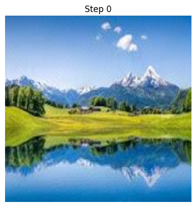

```
Step 50, Loss: 388169236480.0000
```

[figure not shown]

```
Step 100, Loss: 196172857344.0000
```

[figure not shown]

```
Step 150, Loss: 135949737984.0000
```

[figure not shown]

```
Step 200, Loss: 104591114240.0000
```

[figure not shown]

[figure not shown]

```python
import torch
from torchvision import models, transforms
from PIL import Image
import matplotlib.pyplot as plt

# Load image and preprocess
def load_img(path):
    img = Image.open(path).convert('RGB')
    transform = transforms.Compose([
        transforms.Resize((300, 300)),
        transforms.ToTensor()
    ])
    return transform(img).unsqueeze(0)

# Show image
def show_img(tensor, title):
    img = tensor.squeeze().detach().cpu().permute(1, 2, 0).clamp(0, 1)
    plt.imshow(img)
    plt.title(title)
    plt.axis('off')
    plt.show()

# Load content and style images
content = load_img('content.jpg')
style = load_img('style.jpg')

# Use GPU if available
device = torch.device("cuda" if torch.cuda.is_available() else "cpu")
content = content.to(device)
style = style.to(device)

# Load pre-trained VGG19 model (suppress deprecation warning)
from torchvision.models import vgg19, VGG19_Weights
vgg = vgg19(weights=VGG19_Weights.IMAGENET1K_V1).features.to(device).eval()

# Function to extract features
def get_features(x, layers):
    feats = {}
    for name, layer in vgg._modules.items():
        x = layer(x)
        if name in layers:
            feats[name] = x
    return feats

# Gram matrix function
def gram(x):
    b, c, h, w = x.size()
    x = x.view(c, h * w)
    return torch.mm(x, x.t())

# Specify layers for content and style
content_layer = ['21']
style_layers = ['0', '5', '10', '19', '28']

# Extract and detach features
c_feats = {k: v.detach() for k, v in get_features(content, content_layer).items()}
s_feats = get_features(style, style_layers)
s_grams = {l: gram(s_feats[l]).detach() for l in style_layers}

# Initialize target image
target = content.clone().requires_grad_(True)

# Optimizer
opt = torch.optim.Adam([target], lr=0.01)

# Style transfer loop
for step in range(201):
    t_feats = get_features(target, content_layer + style_layers)

    # Content loss
    c_loss = torch.mean((t_feats['21'] - c_feats['21']) ** 2)

    # Style loss
    s_loss = 0
    for l in style_layers:
        target_gram = gram(t_feats[l])
        style_gram = s_grams[l]
        s_loss += torch.mean((target_gram - style_gram) ** 2)

    # Total loss
    loss = c_loss + 1e6 * s_loss

    # Backpropagation
    opt.zero_grad()
    loss.backward()
    opt.step()

    # Clamp to keep image values in range
    with torch.no_grad():
        target.clamp_(0, 1)

    # Display progress
    if step % 50 == 0:
        print(f"Step {step}, Loss: {loss.item():.4f}")
        show_img(target, f"Step {step}")

# Final result
show_img(target, "Final Stylized Image")
```